# RNA-Ribo divergence conditioned on RNA-Protein divergence

Author: Joyce Hsiao

Last updated: 2015-08-27 12:45:49

```r
library(Biobase)

## Set working directories
dir <- "../"
figdir <- file.path(dir,"figures")
rdadir <- file.path(dir,"rdas")
datadir <- file.path(dir, "data")

## Use broman package for colors
require(broman)
crayon <- brocolors("crayons")

## Load customized packages
require(devtools)
require(Humanzee)
```

# Goal

Here we consider a set of genes with sig. RNA-protein interaction and investigate the contribution of buffering at the translation level to the protein level. Two approaches are discussed

# Gene classification

```r
## Load rdas of LRT results and compute fold change estimates using
## RPKM values before normalization.

## load LRT results of RNA vs. Ribo divergence
load(file.path(rdadir,"TEnew.rda"))

## load LRT results of RNA vs. Protein divergence
load(file.path(rdadir,"rnapro.rda"))


## Compute fold changes based on un-normalized data
## from the object eSetRRP.log2 in eSetRRP.rda
load( file.path(rdadir,"eSetRRP.rda") )

eSet.temp <- eSetRRP.log2[ ,eSetRRP.log2$species!="rhesus"]

fc.mat <- lapply( seq_along( c("human","chimp") ), function(i) {
  ii <- eSet.temp$species == c("human","chimp")[i]
  eSet.tt <- eSet.temp[, ii]
  emat <- lapply( seq_along( c("ribo","rna","protein") ), function(j) {
    jj <- eSet.tt$seqData == c("ribo","rna","protein")[j]
    rowMeans( exprs(eSet.tt[, jj] ), na.rm=TRUE )
  })
  emat <- do.call(cbind, emat)
  colnames(emat) <- c("ribo","rna","protein")
  return( data.frame(emat) )
})
names(fc.mat) <- c("human","chimp")

dmat_unnormed <- data.frame( ribo = fc.mat$human$ribo-fc.mat$chimp$ribo,
                             rna = fc.mat$human$rna-fc.mat$chimp$rna,
                             pro = fc.mat$human$protein-fc.mat$chimp$protein )

xy.rnapro <- data.frame( rna = dmat_unnormed$rna,
                         pro = dmat_unnormed$pro )
xy.riborna <- data.frame( rna = dmat_unnormed$rna,
                          ribo = dmat_unnormed$ribo )
xy.ribopro <- data.frame( ribo = dmat_unnormed$ribo,
                          pro = dmat_unnormed$pro )
```

## RNA vs. Ribo divergence

```r
## Genes with sig. human/chimp difference in divergence between RNA and Ribo
ii_sig_rnaribo <- res.riborna$int.qval < .01

## Genes with RNA > Ribo in effect sizes
ii_rnaGTribo <- abs(xy.riborna$rna) > abs(xy.riborna$ribo)

## Genes with RNA < Ribo in effect sizes
ii_riboGTrna <- abs(xy.riborna$ribo) > abs(xy.riborna$rna)
```

## RNA vs. Protein divergence

```r
## Genes with sig. human/chimp difference in divergence between RNA and protein
ii_sig_rnapro <- res.rnapro$int.qval < .01

## Genes with RNA > Protein in effect sizes
ii_rnaGTpro <- abs(xy.rnapro$rna) > abs(xy.rnapro$pro)

## Genes with RNA < Protein in effect sizes
ii_proGTrna <- abs(xy.rnapro$pro) > abs(xy.rnapro$rna)
```

## Summary table

**Interaction appoach**: take the set of genes with sig. RNA-protein interaction, select a subset of genes with sig. RNA-ribo interaction. Then, we divided the genes into two categories

```
* Buffered at the protein level: abs(RNA fold change) > abs(Protein fold change)
* Non-Buffered at the protein level: abs(RNA fold change) < abs(Protein fold change)
```

```r
interact_mat <-
    matrix(0, 3, 4, dimnames = list(c("Protein bufferd (& sig. RNA-protein)",
                                  "Protein non-buffered (& sig. RNA-protein)",
                                  "No sig. RNA-Protein interaction"),
                                c("Ribo buffered (& sig. RNA-Ribo)",
                                  "Ribo non-buffered (& sig. RNA-Ribo)",
                                  "No sig. RNA-Ribo interaction",
                                  "Row sum")))

interact_mat[1,4] <- sum(ii_sig_rnapro & ii_rnaGTpro)
interact_mat[2,4] <- sum(ii_sig_rnapro & ii_proGTrna)
interact_mat[3,4] <- sum(!ii_sig_rnapro)
# interact_mat[4,4] <- length(ii_sig_rnapro)

# interact_mat[4,1] <- sum(ii_sig_rnapro & ii_sig_rnaribo & ii_rnaGTribo)
# interact_mat[4,2] <- sum(ii_sig_rnapro & ii_sig_rnaribo & ii_riboGTrna)
# interact_mat[4,3] <- sum(ii_sig_rnapro & !ii_sig_rnaribo)

interact_mat[1,1] <- sum(ii_sig_rnapro & ii_rnaGTpro &
                         ii_sig_rnaribo & ii_rnaGTribo)
interact_mat[1,2] <- sum(ii_sig_rnapro & ii_rnaGTpro &
                         ii_sig_rnaribo & ii_riboGTrna)
interact_mat[1,3] <- sum(ii_sig_rnapro & ii_rnaGTpro &
                         !ii_sig_rnaribo)

interact_mat[2,1] <- sum(ii_sig_rnapro & ii_proGTrna &
                           ii_sig_rnaribo & ii_rnaGTribo)
interact_mat[2,2] <- sum(ii_sig_rnapro & ii_proGTrna &
                           ii_sig_rnaribo & ii_riboGTrna)
interact_mat[2,3] <- sum(ii_sig_rnapro & ii_proGTrna &
                           !ii_sig_rnaribo)

interact_mat[3,1] <- sum(!ii_sig_rnapro &
                           ii_sig_rnaribo & ii_rnaGTribo)
interact_mat[3,2] <- sum(!ii_sig_rnapro &
                           ii_sig_rnaribo & ii_riboGTrna)
interact_mat[3,3] <- sum(!ii_sig_rnapro &
                           !ii_sig_rnaribo)

kable(interact_mat)
```

|  | Ribo buffered (& sig. RNA-Ribo) | Ribo non-buffered (& sig. RNA-Ribo) | No sig. RNA-Ribo interaction | Row sum |
| --- | --- | --- | --- | --- |
| Protein bufferd (& sig. RNA-protein) | 57 | 22 | 159 | 238 |
| Protein non-buffered (& sig. RNA-protein) | 2 | 22 | 49 | 73 |
| No sig. RNA-Protein interaction | 129 | 246 | 2502 | 2877 |

**Size approach**: take the set of genes with sig. RNA-protein interaction. Then, we divided the genes into two categories

```
* Buffered at the protein level: abs(RNA fold change) > abs(Protein fold change)
* Non-Buffered at the protein level: abs(RNA fold change) < abs(Protein fold change)
```

```r
size_mat <-
    matrix(0, 3, 3, dimnames = list(c("Protein bufferd (& sig. RNA-protein)",
                                  "Protein non-buffered (& sig. RNA-protein)",
                                  "No sig. RNA-Protein interaction"),
                                c("Ribo buffered (& sig. RNA-Ribo)",
                                  "Ribo non-buffered (& sig. RNA-Ribo)",
                                  "Row sum")))

size_mat[1,1] <- sum(ii_sig_rnapro & ii_rnaGTpro &
                         ii_rnaGTribo)
size_mat[1,2] <- sum(ii_sig_rnapro & ii_rnaGTpro &
                         ii_riboGTrna)
size_mat[1,3] <- sum(ii_sig_rnapro & ii_rnaGTpro)

size_mat[2,1] <- sum(ii_sig_rnapro & ii_proGTrna &
                           ii_rnaGTribo)
size_mat[2,2] <- sum(ii_sig_rnapro & ii_proGTrna &
                           ii_riboGTrna)
size_mat[2,3] <- sum(ii_sig_rnapro & ii_proGTrna)

size_mat[3,1] <- sum(!ii_sig_rnapro &
                           ii_rnaGTribo)
size_mat[3,2] <- sum(!ii_sig_rnapro &
                           ii_riboGTrna)
size_mat[3,3] <- sum(!ii_sig_rnapro)

kable(size_mat)
```

|  | Ribo buffered (& sig. RNA-Ribo) | Ribo non-buffered (& sig. RNA-Ribo) | Row sum |
| --- | --- | --- | --- |
| Protein bufferd (& sig. RNA-protein) | 170 | 68 | 238 |
| Protein non-buffered (& sig. RNA-protein) | 23 | 50 | 73 |
| No sig. RNA-Protein interaction | 1255 | 1622 | 2877 |

# RNA ~ Protein

Among `2877` genes that are neither enhanced nor attenuated at the protein level compared to the RNA level (RNA ~ Protein), we identified `375` genes with significant RNA-Ribo interaction and further classifed these genes as follows

- `129` genes are buffered at the translation level relative to the transcript level, and
- `246` genes are consistent with a pattern of non-buffered genes at the tranlsation level relative to the transcript level.

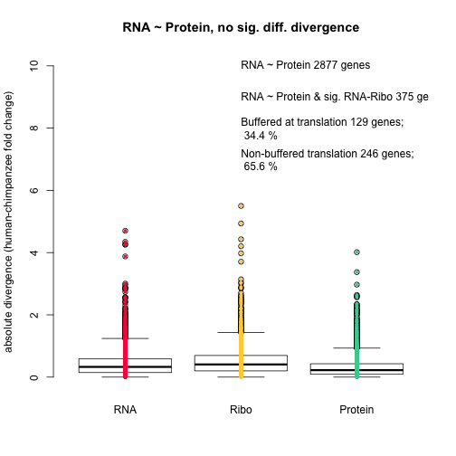

```r
ii_null_rnapro <- !(ii_sig_rnapro)
ii_null_rnapro_ribo_buff <- ii_rnaGTribo & ii_sig_rnaribo & !ii_sig_rnapro
ii_null_rnapro_ribo_nonbuff <- ii_riboGTrna & ii_sig_rnaribo & !ii_sig_rnapro

boxplot(abs(dmat_unnormed$rna[ii_null_rnapro]),
        abs(dmat_unnormed$ribo[ii_null_rnapro]),
        abs(dmat_unnormed$pro[ii_null_rnapro]),
        axes = F, ylim = c(0, 10))
axis(1, at = c(1,2,3), labels = c("RNA", "Ribo", "Protein"),
     col = "white")
axis(2)
points_cols <- c("Scarlet", "Sunglow", "Shamrock")
points(rep(1, sum(ii_null_rnapro)),
       abs(dmat_unnormed$rna[ii_null_rnapro]),
       pch = 19, cex = .5,
       col = crayon[points_cols[1]] )
points(rep(2, sum(ii_null_rnapro)),
       abs(dmat_unnormed$ribo[ii_null_rnapro]),
       pch = 19, cex = .5,
       col = crayon[points_cols[2]] )
points(rep(3, sum(ii_null_rnapro)),
       abs(dmat_unnormed$pro[ii_null_rnapro]),
       pch = 19, cex = .5,
       col = crayon[points_cols[3]] )
text(2, 10, adj = 0,
     label = paste("RNA ~ Protein", sum(ii_null_rnapro), "genes" ) )
text(2, 9, adj = 0,
     label = paste("RNA ~ Protein & sig. RNA-Ribo",
                   sum(ii_null_rnapro & ii_sig_rnaribo), "genes" ) )
text(2, 8, adj = 0,
     label = paste("Buffered at translation",
       sum(ii_null_rnapro_ribo_buff), "genes; \n",
       round(100*sum(ii_null_rnapro_ribo_buff)/
               sum(ii_null_rnapro & ii_sig_rnaribo), 2), "%") )
text(2, 7, adj = 0,
     label = paste("Non-buffered translation",
       sum(ii_null_rnapro_ribo_nonbuff), "genes; \n",
       round(100*sum(ii_null_rnapro_ribo_nonbuff)/
               sum(ii_null_rnapro & ii_sig_rnaribo), 2), "%") )
title(main = "RNA ~ Protein, no sig. diff. divergence",
      ylab = "absolute divergence (human-chimpanzee fold change)")
```

```r
# # Compute pairwise p-values between effect sizes of Ribo, RNA, and protein
# # among genes with RNA ~ Protein
# rna_ribo_t <- t.test( abs(dmat_unnormed$rna[ii_proNULLrna]),
#        abs(dmat_unnormed$ribo[ii_proNULLrna]), paired = TRUE )
# rna_pro_t <- t.test( abs(dmat_unnormed$rna[ii_proNULLrna]),
#        abs(dmat_unnormed$pro[ii_proNULLrna]), paired = TRUE )
# ribo_pro_t <- t.test( abs(dmat_unnormed$ribo[ii_proNULLrna]),
#        abs(dmat_unnormed$pro[ii_proNULLrna]), paired = TRUE )
#
# text(.5, 10, adj = 0,
#      label = paste("Paired t-test of effect sizes") )
# text(.5, 9, adj = 0,
#      label = paste("RNA vs. Ribo: p-value < 1e-14") )
# text(.5, 8, adj = 0,
#      label = paste("RNA vs. Protein: p-value < 1e-15") )
# text(.5, 7, adj = 0,
#      label = paste("Ribo vs. Protein: p-value < 1e-15") )
#
```

## Signal in RNA ~ Protein

```r
## RNA-Ribo buffering or non-buffering
ii_null_rnapro_ribo_buff <- !ii_sig_rnapro & ii_rnaGTribo & ii_sig_rnaribo
ii_null_rnapro_ribo_nonbuff <- !ii_sig_rnapro & ii_riboGTrna & ii_sig_rnaribo

## RNA-Protein buffering or non-buffering
ii_null_rnapro_pro_buff <- !ii_sig_rnapro & ii_rnaGTpro & ii_sig_rnaribo
ii_null_rnapro_pro_nonbuff <- !ii_sig_rnapro & ii_proGTrna & ii_sig_rnaribo

plot_mat <- matrix(0, 2, 2)
rownames(plot_mat) <- c("RNA-Ribo buffered", "RNA-Ribo non-buffered")
colnames(plot_mat) <- c("RNA-Protein buffered", "RNA-Protein non-buffered")

plot_mat[1,1] <- sum(ii_null_rnapro_ribo_buff & ii_null_rnapro_pro_buff)
plot_mat[1,2] <- sum(ii_null_rnapro_ribo_buff & ii_null_rnapro_pro_nonbuff)
plot_mat[2,1] <- sum(ii_null_rnapro_ribo_nonbuff & ii_null_rnapro_pro_buff)
plot_mat[2,2] <- sum(ii_null_rnapro_ribo_nonbuff & ii_null_rnapro_pro_nonbuff)

kable(plot_mat)
```

|  | RNA-Protein buffered | RNA-Protein non-buffered |
| --- | --- | --- |
| RNA-Ribo buffered | 126 | 3 |
| RNA-Ribo non-buffered | 153 | 93 |

### Buffered at translation

Among the `129` genes that were buffered at the translation level relative to the transcript level, we tested the null hypothesis that these genes are as likely to be buffered as to be non-buffered at the protein level relative to the transcript level (RNA-Protein). If this null hypothesis were rejected and the number of genes that were buffered at the protein layer is larger than the number of non-buffered genes at the protein layer, then we say that buffering at the translation level is more likey to co-occur with buffering at the protein level than with non-buffering at the protein level.

```r
prop.test(plot_mat[1,1], rowSums(plot_mat)[1])
```

```r
##
##  1-sample proportions test with continuity correction
##
## data:  plot_mat[1, 1] out of rowSums(plot_mat)[1], null probability 0.5
## X-squared = 115.38, df = 1, p-value < 2.2e-16
## alternative hypothesis: true p is not equal to 0.5
## 95 percent confidence interval:
##  0.9283673 0.9939747
## sample estimates:
##         p
## 0.9767442
```

### Not buffered at translation

Among the `246` genes that were not buffered at translation, we tested the null hypothesis that these genes are as likely to be non-buffered as to be buffered at the protein layer. If this null hypothesis were rejected and the number of genes that were not buffered at the protein layer is more than those buffered at the protein layer, then we say that genes that are non-buffered at the translation level are more likely to be non-buffered at the protein level than to be buffered at the protein level.

```r
## One-proportion z-test
prop.test(plot_mat[2,2], rowSums(plot_mat)[2])
```

```r
##
##  1-sample proportions test with continuity correction
##
## data:  plot_mat[2, 2] out of rowSums(plot_mat)[2], null probability 0.5
## X-squared = 14.15, df = 1, p-value = 0.0001688
## alternative hypothesis: true p is not equal to 0.5
## 95 percent confidence interval:
##  0.3178295 0.4421430
## sample estimates:
##         p
## 0.3780488
```

```r
## Exact test of proportions (binomial test)
binom.test(plot_mat[2,2], rowSums(plot_mat)[2])
```

```r
##
##  Exact binomial test
##
## data:  plot_mat[2, 2] and rowSums(plot_mat)[2]
## number of successes = 93, number of trials = 246, p-value =
## 0.0001576
## alternative hypothesis: true probability of success is not equal to 0.5
## 95 percent confidence interval:
##  0.3172214 0.4418534
## sample estimates:
## probability of success
##              0.3780488
```

# RNA > Protein

Among the genes that are buffered at the protein level compared to the RNA level (RNA > protein), we are interested in the number of genes with buffered translation. In other words, we ask whether genes that were buffered at the protein level were more likely to be enriched with genes buffered at the translation level.

For the hypothesis testing, we compute the expected proportion of genes enriched at the translation level among the genes that were buffered at the protein level in the set of genes where there is no significant interaction between RNA and protein (`2877` genes).

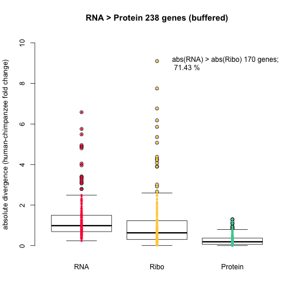

```r
boxplot(abs(dmat_unnormed$rna[ii_rnaGTpro & ii_sig_rnapro]),
        abs(dmat_unnormed$ribo[ii_rnaGTpro & ii_sig_rnapro]),
        abs(dmat_unnormed$pro[ii_rnaGTpro & ii_sig_rnapro]),
        axes = F, ylim = c(0, 10))
axis(1, at = c(1,2,3), labels = c("RNA", "Ribo", "Protein"),
     col = "white")
axis(2)
points_cols <- c("Scarlet", "Sunglow", "Shamrock")
points(rep(1, sum(ii_rnaGTpro & ii_sig_rnapro)),
       abs(dmat_unnormed$rna[ii_rnaGTpro & ii_sig_rnapro]),
       pch = 19, cex = .5,
       col = crayon[points_cols[1]] )
points(rep(2, sum(ii_rnaGTpro & ii_sig_rnapro)),
       abs(dmat_unnormed$ribo[ii_rnaGTpro & ii_sig_rnapro]),
       pch = 19, cex = .5,
       col = crayon[points_cols[2]] )
points(rep(3, sum(ii_rnaGTpro & ii_sig_rnapro)),
       abs(dmat_unnormed$pro[ii_rnaGTpro & ii_sig_rnapro]),
       pch = 19, cex = .5,
       col = crayon[points_cols[3]] )
text(2.2, 9, adj = 0,
     label = paste("abs(RNA) > abs(Ribo)",
      sum( ii_rnaGTpro & ii_sig_rnapro & ii_rnaGTribo ), "genes; \n",
      round( 100*sum(ii_rnaGTpro & ii_sig_rnapro & ii_rnaGTribo)/
             sum(ii_rnaGTpro & ii_sig_rnapro), 2),"%") )
title(main = paste("RNA > Protein",sum(ii_rnaGTpro & ii_sig_rnapro),
                   "genes (buffered)"),
      ylab = "absolute divergence (human-chimpanzee fold change)")
```

```r
## Null proportion of RNA-Protein attenuated | RNA-Ribo attenuated
rnapro_null_pro_buff <- plot_mat[1, 1]/rowSums(plot_mat)[1]


prop.test( sum(ii_rnaGTpro & ii_sig_rnapro & ii_rnaGTribo),
           sum(ii_rnaGTpro & ii_sig_rnapro), p = rnapro_null_pro_buff)
```

```r
##
##  1-sample proportions test with continuity correction
##
## data:  sum(ii_rnaGTpro & ii_sig_rnapro & ii_rnaGTribo) out of sum(ii_rnaGTpro & ii_sig_rnapro), null probability rnapro_null_pro_buff
## X-squared = 710.24, df = 1, p-value < 2.2e-16
## alternative hypothesis: true p is not equal to 0.9767442
## 95 percent confidence interval:
##  0.6516545 0.7698627
## sample estimates:
##         p
## 0.7142857
```

```r
binom.test( sum(ii_rnaGTpro & ii_sig_rnapro & ii_rnaGTribo),
           sum(ii_rnaGTpro & ii_sig_rnapro), p = rnapro_null_pro_buff)
```

```r
##
##  Exact binomial test
##
## data:  sum(ii_rnaGTpro & ii_sig_rnapro & ii_rnaGTribo) and sum(ii_rnaGTpro & ii_sig_rnapro)
## number of successes = 170, number of trials = 238, p-value <
## 2.2e-16
## alternative hypothesis: true probability of success is not equal to 0.9767442
## 95 percent confidence interval:
##  0.6523599 0.7707854
## sample estimates:
## probability of success
##              0.7142857
```

# RNA < Protein

For the hypothesis testing, we compute the expected proportion of genes enriched at the translation level among the genes that were not buffered at the protein level in the set of genes where there is no significant interaction between RNA and protein (`2877` genes).

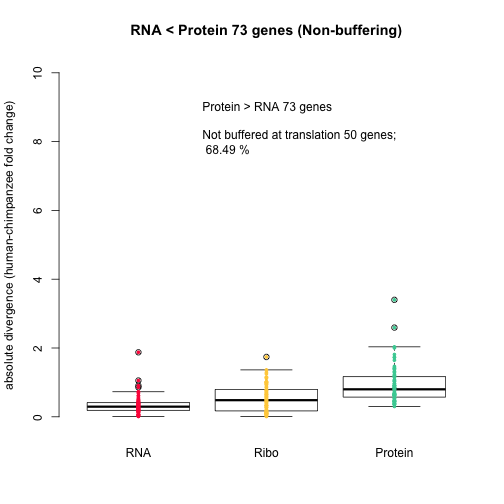

```r
boxplot(abs(dmat_unnormed$rna[ii_proGTrna & ii_sig_rnapro]),
        abs(dmat_unnormed$ribo[ii_proGTrna & ii_sig_rnapro]),
        abs(dmat_unnormed$pro[ii_proGTrna & ii_sig_rnapro]),
        axes = F, ylim = c(0, 10))
axis(1, at = c(1,2,3), labels = c("RNA", "Ribo", "Protein"),
     col = "white")
axis(2)
points_cols <- c("Scarlet", "Sunglow", "Shamrock")
points(rep(1, sum(ii_proGTrna & ii_sig_rnapro)),
       abs(dmat_unnormed$rna[ii_proGTrna & ii_sig_rnapro]),
       pch = 19, cex = .5,
       col = crayon[points_cols[1]] )
points(rep(2, sum(ii_proGTrna & ii_sig_rnapro)),
       abs(dmat_unnormed$ribo[ii_proGTrna & ii_sig_rnapro]),
       pch = 19, cex = .5,
       col = crayon[points_cols[2]] )
points(rep(3, sum(ii_proGTrna & ii_sig_rnapro)),
       abs(dmat_unnormed$pro[ii_proGTrna & ii_sig_rnapro]),
       pch = 19, cex = .5,
       col = crayon[points_cols[3]] )
text(1.5, 9, adj = 0,
     label = paste("Protein > RNA",
                   sum(ii_proGTrna & ii_sig_rnapro), "genes" ) )
text(1.5, 8, adj = 0,
     label = paste("Not buffered at translation",
      sum(ii_proGTrna & ii_sig_rnapro & ii_riboGTrna), "genes; \n",
      round(100*sum(ii_proGTrna & ii_sig_rnapro & ii_riboGTrna)/
              sum(ii_proGTrna & ii_sig_rnapro),
            2),"%") )
title(main = paste("RNA < Protein",sum(ii_proGTrna & ii_sig_rnapro),
                  "genes (Non-buffering)"),
      ylab = "absolute divergence (human-chimpanzee fold change)")
```

```r
## Null proportion of RNA-Ribo enhanced | RNA-Protein enhanced
rnapro_null_pro_nonbuff <- plot_mat[2,2]/rowSums(plot_mat)[2]

prop.test( sum(ii_proGTrna & ii_sig_rnapro & ii_riboGTrna),
           sum(ii_proGTrna & ii_sig_rnapro), p = rnapro_null_pro_nonbuff)
```

```r
##
##  1-sample proportions test with continuity correction
##
## data:  sum(ii_proGTrna & ii_sig_rnapro & ii_riboGTrna) out of sum(ii_proGTrna & ii_sig_rnapro), null probability rnapro_null_pro_nonbuff
## X-squared = 27.948, df = 1, p-value = 1.246e-07
## alternative hypothesis: true p is not equal to 0.3780488
## 95 percent confidence interval:
##  0.5643375 0.7858814
## sample estimates:
##         p
## 0.6849315
```

```r
binom.test( sum(ii_proGTrna & ii_sig_rnapro & ii_riboGTrna),
           sum(ii_proGTrna & ii_sig_rnapro), p = rnapro_null_pro_nonbuff)
```

```r
##
##  Exact binomial test
##
## data:  sum(ii_proGTrna & ii_sig_rnapro & ii_riboGTrna) and sum(ii_proGTrna & ii_sig_rnapro)
## number of successes = 50, number of trials = 73, p-value =
## 1.584e-07
## alternative hypothesis: true probability of success is not equal to 0.3780488
## 95 percent confidence interval:
##  0.5656134 0.7887043
## sample estimates:
## probability of success
##              0.6849315
```

```r
## R version 3.2.1 (2015-06-18)
## Platform: x86_64-apple-darwin13.4.0 (64-bit)
## Running under: OS X 10.10.4 (Yosemite)
##
## locale:
## [1] en_US.UTF-8/en_US.UTF-8/en_US.UTF-8/C/en_US.UTF-8/en_US.UTF-8
##
## attached base packages:
## [1] parallel  stats     graphics  grDevices utils     datasets  methods
## [8] base
##
## other attached packages:
## [1] Humanzee_0.0.0.9000 devtools_1.9.0      broman_0.59-5
## [4] Biobase_2.28.0      BiocGenerics_0.14.0 knitr_1.11
##
## loaded via a namespace (and not attached):
##  [1] digest_0.6.8         assertthat_0.1       mime_0.3
##  [4] knitrBootstrap_1.0.0 formatR_1.2          magrittr_1.5
##  [7] evaluate_0.7.2       highr_0.5            stringi_0.5-5
## [10] rmarkdown_0.7        tools_3.2.1          stringr_1.0.0
## [13] markdown_0.7.7       yaml_2.1.13          memoise_0.2.1
## [16] htmltools_0.2.6
```

Styled with knitrBootstrap